# ERT Pilot Exploratory Results

False Cardiac Feedback Paradigm By-subject aggregation

Guido Maria Caruso

2026-08-11

```r
library(tidyverse)
library(ez)
library(knitr)
library(kableExtra)
library(ggplot2)
```

# Overview

This report presents exploratory analyses of pilot data from the **ERT task** (Emotion Recognition Task with False Cardiac Feedback).

**Paradigm:** Participants rated the emotional intensity of facial expressions (happiness, anger, fear) while receiving auditory feedback at rates **faster**, **slower**, or **synchronous** with their actual heart rate.

**Key hypothesis:** False feedback (faster or slower than veridical HR) should progressively bias emotional intensity ratings over the course of each stimulation block, i.e. an *exposure effect* reflecting interoceptive embodiment.

```r
df_raw <- list.files(path = ".", pattern = "FULL\\.csv$", full.names = TRUE) |>
  map_dfr(read_csv, show_col_types = FALSE,
          col_types = cols(participant_id = col_character())) |>
  filter(segment_type == "main") |>
  mutate(
    participant_id = as.factor(participant_id),
    condition      = factor(condition,
                            levels = c("synchronous", "faster", "slower")),
    valence        = factor(ifelse(emotion == "happiness", "positive", "negative"),
                            levels = c("positive", "negative")),
    trial_in_mini_f = as.factor(as.numeric(trial_in_mini)),
    vas_value      = as.numeric(vas_value),
    rt             = as.numeric(rt)
  )

df <- df_raw |>
  group_by(participant_id, condition, valence) |>
  summarise(vas_m = mean(vas_value, na.rm = TRUE),
            rt_m  = mean(rt, na.rm = TRUE),
            .groups = "drop")

df_ts <- df_raw |>
  group_by(participant_id, condition, valence, trial_in_mini_f) |>
  summarise(vas_m = mean(vas_value, na.rm = TRUE),
            rt_m  = mean(rt, na.rm = TRUE),
            .groups = "drop")
```

**N participants:** 30  
**N trials (raw):** 10800  
**Rows after aggregation:** 180 (30 participants × 3 conditions × 2 valences)

# 1. Descriptives

## VAS by condition × valence

```r
df |>
  group_by(condition, valence) |>
  summarise(M  = round(mean(vas_m), 2),
            SD = round(sd(vas_m), 2),
            n  = n(), .groups = "drop") |>
  kable(caption = "Mean VAS per condition x valence (participant means)") |>
  kable_styling(bootstrap_options = c("striped","hover"), full_width = FALSE)
```

Mean VAS per condition x valence (participant means)

| condition | valence | M | SD | n |
| --- | --- | --- | --- | --- |
| synchronous | positive | 21.47 | 7.39 | 30 |
| synchronous | negative | -26.07 | 10.23 | 30 |
| faster | positive | 21.40 | 8.19 | 30 |
| faster | negative | -26.32 | 10.69 | 30 |
| slower | positive | 21.19 | 6.68 | 30 |
| slower | negative | -26.70 | 9.65 | 30 |

## RT by condition × valence

```r
df |>
  group_by(condition, valence) |>
  summarise(M  = round(mean(rt_m), 3),
            SD = round(sd(rt_m), 3),
            n  = n(), .groups = "drop") |>
  kable(caption = "Mean RT per condition x valence (participant means)") |>
  kable_styling(bootstrap_options = c("striped","hover"), full_width = FALSE)
```

Mean RT per condition x valence (participant means)

| condition | valence | M | SD | n |
| --- | --- | --- | --- | --- |
| synchronous | positive | 1.511 | 0.609 | 30 |
| synchronous | negative | 1.546 | 0.626 | 30 |
| faster | positive | 1.416 | 0.516 | 30 |
| faster | negative | 1.378 | 0.546 | 30 |
| slower | positive | 1.462 | 0.583 | 30 |
| slower | negative | 1.437 | 0.614 | 30 |

# 2. Sanity check - intensity × VAS

VAS ratings should correlate strongly with stimulus intensity within each valence: positive faces should yield higher ratings at higher intensities, negative faces lower ratings.

```r
df_raw |>
  mutate(intensity = as.numeric(intensity)) |>
  group_by(valence) |>
  summarise(
    rho = round(cor(intensity, vas_value, method = "spearman"), 3),
    p   = case_when(
      cor.test(intensity, vas_value, method = "spearman")$p.value < 0.001 ~ "< .001",
      TRUE ~ sprintf("%.4f",
                     cor.test(intensity, vas_value, method = "spearman")$p.value)
    ),
    .groups = "drop"
  ) |>
  kable(caption = "Spearman correlation: stimulus intensity ~ VAS rating") |>
  kable_styling(bootstrap_options = c("striped","hover"), full_width = FALSE)
```

Spearman correlation: stimulus intensity ~ VAS rating

| valence | rho | p |
| --- | --- | --- |
| positive | 0.745 | < .001 |
| negative | -0.613 | < .001 |

# 3. rmANOVA - VAS

Repeated-measures ANOVA on participant-level VAS means. testing whether **condition** or its interaction with **valence** reaches significance. No main effect of condition is expected at this sample size while the exposure effect is expected to emerge in the time-series analysis (Section 6).

```r
anova_vas <- ezANOVA(
  data     = df,
  dv       = vas_m,
  wid      = participant_id,
  within   = .(condition, valence),
  type     = 3,
  detailed = TRUE
)
bold_ezanova(anova_vas)
```

Effect

DFn

DFd

SSn

SSd

F

p

p<.05

ges

condition

2

58

6.261

1152.563

0.1575

0.8546

0.0005

valence

1

29

102464.219

7868.706

377.6304

< .001

0.8807

condition:valence

2

58

0.909

594.970

0.0443

0.9567

0.0001

> **Bold rows** = p < .05. `ges` = generalised eta squared (effect size).

### Sphericity corrections (Greenhouse-Geisser)

```r
anova_vas$`Sphericity Corrections` |>
  mutate(across(where(is.numeric), ~ round(., 4))) |>
  kable() |>
  kable_styling(bootstrap_options = c("striped","hover"), full_width = FALSE)
```

|  | Effect | GGe | p[GG] | p[GG]<.05 | HFe | p[HF] | p[HF]<.05 |
| --- | --- | --- | --- | --- | --- | --- | --- |
| 2 | condition | 1.0000 | 0.8546 |  | 1.0740 | 0.8546 |  |
| 4 | condition:valence | 0.8494 | 0.9361 |  | 0.8967 | 0.9435 |  |

# 4. rmANOVA - RT

Reaction times may reflect decision certainty: if false feedback increases perceptual ambiguity, participants may respond more slowly in faster/slower conditions compared to synchronous.

```r
anova_rt <- ezANOVA(
  data     = df,
  dv       = rt_m,
  wid      = participant_id,
  within   = .(condition, valence),
  type     = 3,
  detailed = TRUE
)
bold_ezanova(anova_rt)
```

| Effect | DFn | DFd | SSn | SSd | F | p | p<.05 | ges |
| --- | --- | --- | --- | --- | --- | --- | --- | --- |
| condition | 2 | 58 | 0.524 | 4.951 | 3.0686 | 0.0541 |  | 0.0088 |
| valence | 1 | 29 | 0.004 | 0.887 | 0.1227 | 0.7287 |  | 0.0001 |
| condition:valence | 2 | 58 | 0.046 | 0.809 | 1.6484 | 0.2012 |  | 0.0008 |

> **Bold rows** = p < .05. `ges` = generalised eta squared (effect size).

### Sphericity corrections (Greenhouse-Geisser)

```r
anova_rt$`Sphericity Corrections` |>
  mutate(across(where(is.numeric), ~ round(., 4))) |>
  kable() |>
  kable_styling(bootstrap_options = c("striped","hover"), full_width = FALSE)
```

|  | Effect | GGe | p[GG] | p[GG]<.05 | HFe | p[HF] | p[HF]<.05 |
| --- | --- | --- | --- | --- | --- | --- | --- |
| 2 | condition | 0.9202 | 0.0588 |  | 0.9796 | 0.0553 |  |
| 4 | condition:valence | 0.9312 | 0.2033 |  | 0.9926 | 0.2015 |  |

# 5. Visualisations

## VAS per condition × valence

Each line represents one participant’s trajectory across conditions. The dashed black line shows the grand mean.

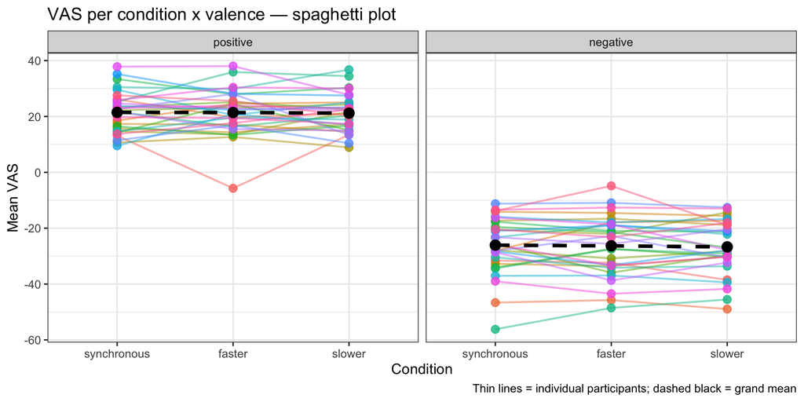

```r
df |>
  ggplot(aes(x = condition, y = vas_m, group = participant_id)) +
  geom_line(aes(color = participant_id), alpha = 0.5, linewidth = 0.8) +
  geom_point(aes(color = participant_id), size = 3, alpha = 0.8) +
  stat_summary(aes(group = 1), fun = mean, geom = "line",
               linewidth = 1.5, color = "black", linetype = "dashed") +
  stat_summary(aes(group = 1), fun = mean, geom = "point",
               size = 4, color = "black") +
  facet_wrap(~ valence) +
  labs(title = "VAS per condition x valence — spaghetti plot",
       x = "Condition", y = "Mean VAS",
       caption = "Thin lines = individual participants; dashed black = grand mean") +
  theme_bw(base_size = 13) +
  theme(legend.position = "none")
```

## RT per condition × valence

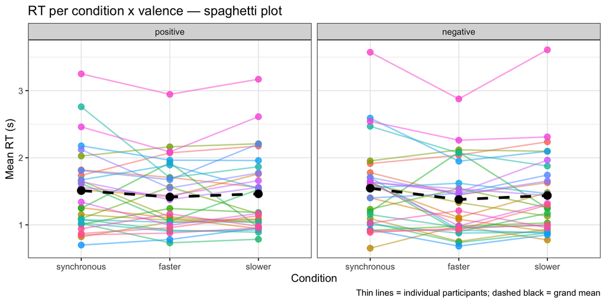

```r
df |>
  ggplot(aes(x = condition, y = rt_m, group = participant_id)) +
  geom_line(aes(color = participant_id), alpha = 0.5, linewidth = 0.8) +
  geom_point(aes(color = participant_id), size = 3, alpha = 0.8) +
  stat_summary(aes(group = 1), fun = mean, geom = "line",
               linewidth = 1.5, color = "black", linetype = "dashed") +
  stat_summary(aes(group = 1), fun = mean, geom = "point",
               size = 4, color = "black") +
  facet_wrap(~ valence) +
  labs(title = "RT per condition x valence — spaghetti plot",
       x = "Condition", y = "Mean RT (s)",
       caption = "Thin lines = individual participants; dashed black = grand mean") +
  theme_bw(base_size = 13) +
  theme(legend.position = "none")
```

# 6. Exposure effect - time series within block

We examined whether the effect of false feedback develops progressively over the course of each stimulation block. Trial position within the block (1–6) captures this *exposure effect*: early trials have had less exposure to the feedback signal, while later trials have been exposed longer.

Data are aggregated to **participant means per condition × valence × trial position**.

```r
cat("Rows after aggregation:", nrow(df_ts),
    "=", n_distinct(df_ts$participant_id),
    "participants x 3 conditions x 2 valences x 6 trial positions\n")
```

```
## Rows after aggregation: 1080 = 30 participants x 3 conditions x 2 valences x 6 trial positions
```

## rmANOVA - VAS with trial position

The key effect of interest is the **condition × valence × trial_in_mini** interaction.

```r
anova_vas_ts <- ezANOVA(
  data   = df_ts,
  dv     = vas_m,
  wid    = participant_id,
  within = .(condition, valence, trial_in_mini_f),
  type   = 3,
  detailed = TRUE
)
bold_ezanova(anova_vas_ts)
```

Effect

DFn

DFd

SSn

SSd

F

p

p<.05

ges

condition

2

58

38.763

6782.811

0.1657

0.8477

0.0002

valence

1

29

613145.875

47320.631

375.7606

< .001

0.7794

trial_in_mini_f

5

145

343.016

16742.907

0.5941

0.7045

0.0020

condition:valence

2

58

18.838

4022.260

0.1358

0.8733

0.0001

condition:trial_in_mini_f

10

290

2110.990

28247.411

2.1672

0.0198

0.0120

valence:trial_in_mini_f

5

145

797.421

15855.057

1.4585

0.2070

0.0046

condition:valence:trial_in_mini_f

10

290

1271.653

28836.801

1.2789

0.2418

0.0073

## rmANOVA - RT with trial position

```r
anova_rt_ts <- ezANOVA(
  data   = df_ts,
  dv     = rt_m,
  wid    = participant_id,
  within = .(condition, valence, trial_in_mini_f),
  type   = 3,
  detailed = TRUE
)
bold_ezanova(anova_rt_ts)
```

Effect

DFn

DFd

SSn

SSd

F

p

p<.05

ges

condition

2

58

3.127

29.018

3.1255

0.0514

0.0073

valence

1

29

0.070

5.045

0.4039

0.5301

0.0002

trial_in_mini_f

5

145

3.017

13.905

6.2922

< .001

0.0071

condition:valence

2

58

0.150

5.931

0.7330

0.4848

0.0004

condition:trial_in_mini_f

10

290

1.251

20.266

1.7901

0.0620

0.0029

valence:trial_in_mini_f

5

145

0.771

14.622

1.5295

0.1842

0.0018

condition:valence:trial_in_mini_f

10

290

0.526

21.279

0.7163

0.7090

0.0012

## Plot - VAS exposure effect

If false feedback is being embodied as an interoceptive arousal signal, VAS ratings should diverge across conditions over the course of each block.

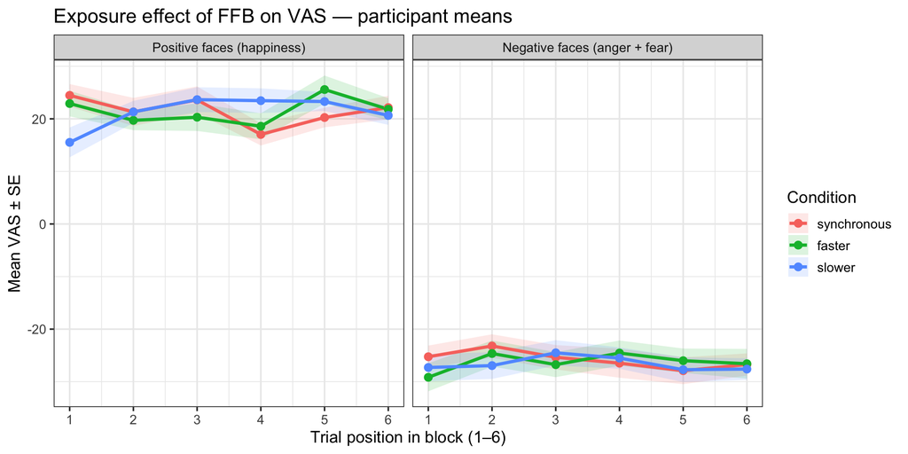

```r
df_ts |>
  group_by(condition, valence, trial_in_mini_f) |>
  summarise(M  = mean(vas_m),
            SE = sd(vas_m) / sqrt(n()),
            .groups = "drop") |>
  ggplot(aes(x = as.numeric(as.character(trial_in_mini_f)),
             y = M, color = condition, group = condition)) +
  geom_ribbon(aes(ymin = M - SE, ymax = M + SE, fill = condition),
              alpha = 0.15, color = NA) +
  geom_line(linewidth = 1.2) +
  geom_point(size = 2.5) +
  facet_wrap(~ valence, labeller = labeller(
    valence = c(positive = "Positive faces (happiness)",
                negative = "Negative faces (anger + fear)"))) +
  scale_x_continuous(breaks = 1:6) +
  labs(title = "Exposure effect of FFB on VAS — participant means",
       x = "Trial position in block (1–6)",
       y = "Mean VAS ± SE",
       color = "Condition", fill = "Condition") +
  theme_bw(base_size = 13)
```

## Plot - RT exposure effect

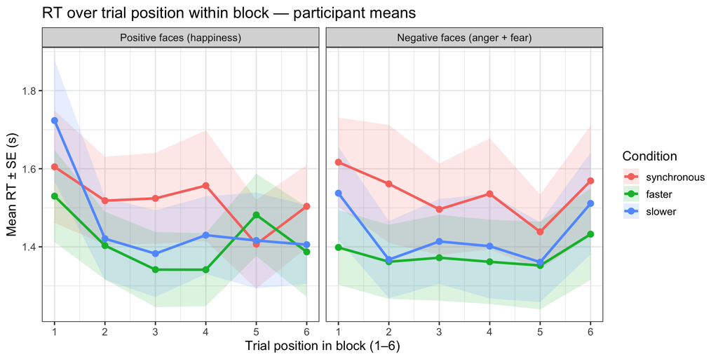

```r
df_ts |>
  group_by(condition, valence, trial_in_mini_f) |>
  summarise(M  = mean(rt_m),
            SE = sd(rt_m) / sqrt(n()),
            .groups = "drop") |>
  ggplot(aes(x = as.numeric(as.character(trial_in_mini_f)),
             y = M, color = condition, group = condition)) +
  geom_ribbon(aes(ymin = M - SE, ymax = M + SE, fill = condition),
              alpha = 0.15, color = NA) +
  geom_line(linewidth = 1.2) +
  geom_point(size = 2.5) +
  facet_wrap(~ valence, labeller = labeller(
    valence = c(positive = "Positive faces (happiness)",
                negative = "Negative faces (anger + fear)"))) +
  scale_x_continuous(breaks = 1:6) +
  labs(title = "RT over trial position within block — participant means",
       x = "Trial position in block (1–6)",
       y = "Mean RT ± SE (s)",
       color = "Condition", fill = "Condition") +
  theme_bw(base_size = 13)
```

## Plot: VAS exposure effect - spaghetti per participant

Each line shows one participant’s trajectory across trial positions within the block.

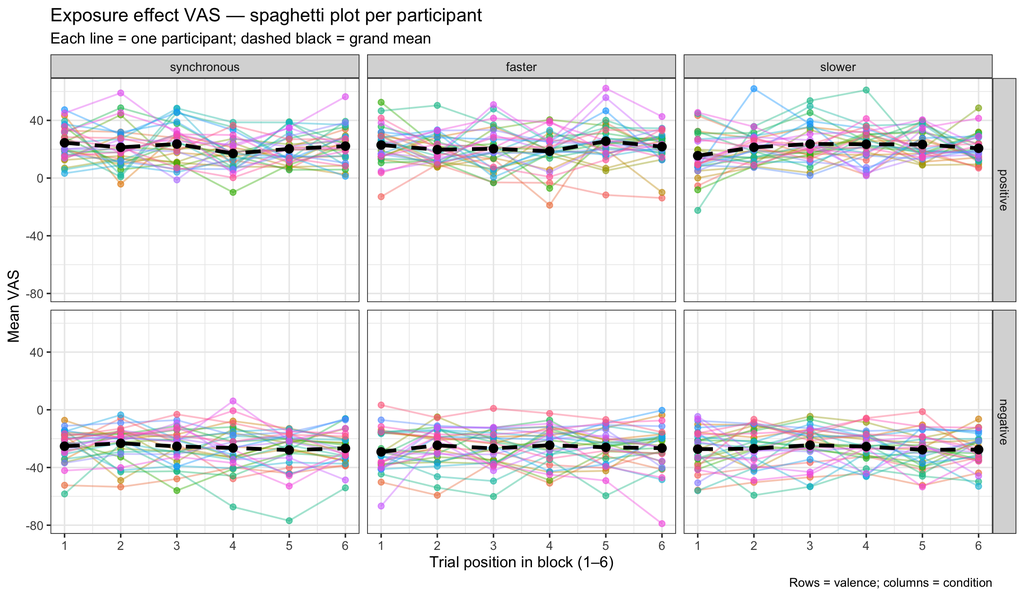

```r
df_ts |>
  mutate(trial_in_mini = as.numeric(as.character(trial_in_mini_f))) |>
  ggplot(aes(x = trial_in_mini, y = vas_m,
             group = participant_id, color = participant_id)) +
  geom_line(alpha = 0.4, linewidth = 0.7) +
  geom_point(alpha = 0.6, size = 2) +
  stat_summary(aes(group = 1), fun = mean, geom = "line",
               linewidth = 1.5, color = "black", linetype = "dashed") +
  stat_summary(aes(group = 1), fun = mean, geom = "point",
               size = 3, color = "black") +
  facet_grid(valence ~ condition) +
  scale_x_continuous(breaks = 1:6) +
  labs(title = "Exposure effect VAS — spaghetti plot per participant",
       subtitle = "Each line = one participant; dashed black = grand mean",
       x = "Trial position in block (1–6)",
       y = "Mean VAS",
       caption = "Rows = valence; columns = condition") +
  theme_bw(base_size = 13) +
  theme(legend.position = "none")
```

## Plot: RT exposure effect - spaghetti per participant

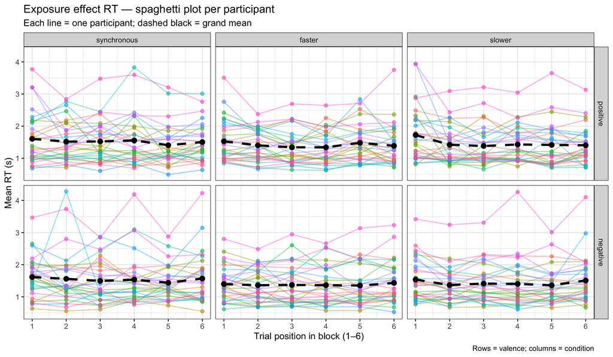

```r
df_ts |>
  mutate(trial_in_mini = as.numeric(as.character(trial_in_mini_f))) |>
  ggplot(aes(x = trial_in_mini, y = rt_m,
             group = participant_id, color = participant_id)) +
  geom_line(alpha = 0.4, linewidth = 0.7) +
  geom_point(alpha = 0.6, size = 2) +
  stat_summary(aes(group = 1), fun = mean, geom = "line",
               linewidth = 1.5, color = "black", linetype = "dashed") +
  stat_summary(aes(group = 1), fun = mean, geom = "point",
               size = 3, color = "black") +
  facet_grid(valence ~ condition) +
  scale_x_continuous(breaks = 1:6) +
  labs(title = "Exposure effect RT — spaghetti plot per participant",
       subtitle = "Each line = one participant; dashed black = grand mean",
       x = "Trial position in block (1–6)",
       y = "Mean RT (s)",
       caption = "Rows = valence; columns = condition") +
  theme_bw(base_size = 13) +
  theme(legend.position = "none")
```

## Plot of Within-block slopes VAS per condition × valence

Regression lines show the within-block trajectory for each participant (thin lines) and the group trend (thick line ± SE). A positive slope means VAS ratings increase over the course of the block; a negative slope means they decrease. Diverging slopes across conditions are the visual sign of the exposure effect.

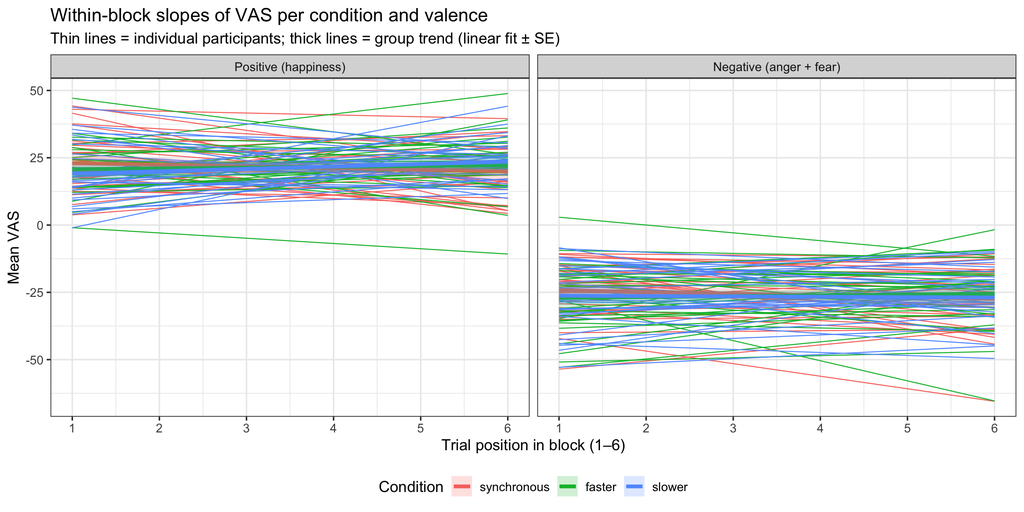

```r
df_ts |>
  mutate(trial_num = as.numeric(as.character(trial_in_mini_f))) |>
  ggplot(aes(x = trial_num, y = vas_m,
             color = condition, fill = condition)) +
  geom_smooth(aes(group = interaction(participant_id, condition)),
              method = "lm", se = FALSE,
              linewidth = 0.4, alpha = 0.3) +
  geom_smooth(aes(group = condition),
              method = "lm", se = TRUE,
              linewidth = 1.5, alpha = 0.2) +
  facet_wrap(~ valence, labeller = labeller(
    valence = c(positive = "Positive (happiness)",
                negative = "Negative (anger + fear)"))) +
  scale_x_continuous(breaks = 1:6) +
  labs(title = "Within-block slopes of VAS per condition and valence",
       subtitle = "Thin lines = individual participants; thick lines = group trend (linear fit ± SE)",
       x = "Trial position in block (1–6)",
       y = "Mean VAS",
       color = "Condition", fill = "Condition") +
  theme_bw(base_size = 13) +
  theme(legend.position = "bottom")
```

**Step 1:** Split by condition, does valence × trial interact within each condition?

```r
split_results <- map_dfr(c("synchronous", "faster", "slower"), function(cond) {
  sub <- df_ts |> filter(condition == cond)
  m <- ezANOVA(
    data     = sub,
    dv       = vas_m,
    wid      = participant_id,
    within   = .(valence, trial_in_mini_f),
    type     = 3,
    detailed = TRUE
  )
  row <- m$ANOVA |> filter(Effect == "valence:trial_in_mini_f")
  tibble(
    Condition = cond,
    F         = round(row$F, 3),
    DFn       = row$DFn,
    DFd       = row$DFd,
    p         = round(row$p, 4)
  )
})

split_results |>
  kable(caption = "valence x trial interaction within each condition") |>
  kable_styling(bootstrap_options = c("striped","hover"), full_width = FALSE) |>
  row_spec(which(split_results$p < 0.05), bold = TRUE)
```

valence x trial interaction within each condition

| Condition | F | DFn | DFd | p |
| --- | --- | --- | --- | --- |
| synchronous | 1.008 | 5 | 145 | 0.4152 |
| faster | 2.059 | 5 | 145 | 0.0739 |
| slower | 1.012 | 5 | 145 | 0.4131 |

**Step 2:** Split by condition × valence, in which specific cell is the within-block slope significant?

```r
slope_results <- map_dfr(c("faster", "slower"), function(cond) {
  map_dfr(c("positive", "negative"), function(val) {
    sub <- df_ts |>
      filter(condition == cond, valence == val) |>
      mutate(trial_num = as.numeric(as.character(trial_in_mini_f)))
    m <- lmer(vas_m ~ trial_num + (1 | participant_id), data = sub)
    s <- summary(m)$coefficients
    tibble(
      Condition = cond,
      Valence   = val,
      Beta      = round(s[2, 1], 3),
      SE        = round(s[2, 2], 3),
      p         = round(s[2, 5], 4)
    )
  })
})

slope_results |>
  mutate(p_fmt = case_when(p < 0.001 ~ "< .001", TRUE ~ sprintf("%.4f", p))) |>
  select(Condition, Valence, Beta, SE, p = p_fmt) |>
  kable(caption = "Within-block slope (trial 1-6) per condition x valence") |>
  kable_styling(bootstrap_options = c("striped","hover"), full_width = FALSE) |>
  row_spec(which(slope_results$p < 0.05), bold = TRUE)
```

Within-block slope (trial 1-6) per condition x valence

| Condition | Valence | Beta | SE | p |
| --- | --- | --- | --- | --- |
| faster | positive | 0.298 | 0.486 | 0.5407 |
| faster | negative | 0.315 | 0.409 | 0.4428 |
| slower | positive | 0.897 | 0.505 | 0.0777 |
| slower | negative | -0.140 | 0.395 | 0.7240 |

# 8. Exploratory — Exposure effect by stimulus intensity

False feedback should have the greatest impact on **ambiguous stimuli** (low intensity), where perceptual uncertainty is highest and the interoceptive signal can tip the balance. For strongly valenced stimuli (high intensity), the emotional signal is unambiguous and should be less susceptible to false feedback.

Stimuli are split into three categories: - **Low** (intensity 0–4): emotionally ambiguous, close to neutral - **Medium** (intensity 6–12): moderately valenced - **High** (intensity 16–20): strongly valenced, unambiguous

```r
df_raw <- df_raw |>
  mutate(
    intensity_cat = case_when(
      intensity <= 4  ~ "low",
      intensity <= 12 ~ "medium",
      intensity >= 16 ~ "high"
    ) |> factor(levels = c("low", "medium", "high"))
  )

table(df_raw$intensity_cat) |>
  as.data.frame() |>
  rename(Intensity = Var1, N = Freq) |>
  kable(caption = "Trial count per intensity category") |>
  kable_styling(bootstrap_options = c("striped","hover"), full_width = FALSE)
```

Trial count per intensity category

| Intensity | N |
| --- | --- |
| low | 4320 |
| medium | 4320 |
| high | 2160 |

## Within-block slopes per condition × valence — Low intensity only

```r
df_low_ts <- df_raw |>
  filter(intensity_cat == "low") |>
  group_by(participant_id, condition, valence, trial_in_mini_f) |>
  summarise(vas_m = mean(vas_value, na.rm = TRUE), .groups = "drop") |>
  mutate(trial_num = as.numeric(as.character(trial_in_mini_f)))

slope_low <- map_dfr(c("faster","slower","synchronous"), function(cond) {
  map_dfr(c("positive","negative"), function(val) {
    sub <- df_low_ts |> filter(condition == cond, valence == val)
    m <- lmer(vas_m ~ trial_num + (1 | participant_id), data = sub)
    s <- summary(m)$coefficients
    tibble(Condition = cond, Valence = val,
           Beta = round(s[2,1],3), SE = round(s[2,2],3),
           p_raw = s[2,5])
  })
}) |> mutate(p = case_when(p_raw < 0.001 ~ "< .001",
                            TRUE ~ sprintf("%.4f", p_raw))) |>
  select(-p_raw)

slope_low |>
  kable(caption = "Within-block slopes — Low intensity stimuli (0–4)") |>
  kable_styling(bootstrap_options = c("striped","hover"), full_width = FALSE) |>
  row_spec(which(
    map_dfr(c("faster","slower","synchronous"), function(cond) {
      map_dfr(c("positive","negative"), function(val) {
        sub <- df_low_ts |> filter(condition == cond, valence == val)
        m <- lmer(vas_m ~ trial_num + (1 | participant_id), data = sub)
        tibble(p = summary(m)$coefficients[2,5])
      })
    }) |> pull(p) < 0.05
  ), bold = TRUE)
```

Within-block slopes — Low intensity stimuli (0–4)

| Condition | Valence | Beta | SE | p |
| --- | --- | --- | --- | --- |
| faster | positive | -0.116 | 0.503 | 0.8173 |
| faster | negative | 0.694 | 0.474 | 0.1448 |
| slower | positive | 0.741 | 0.425 | 0.0836 |
| slower | negative | -0.339 | 0.461 | 0.4637 |
| synchronous | positive | -0.585 | 0.471 | 0.2163 |
| synchronous | negative | -0.114 | 0.524 | 0.8276 |

## Within-block slopes per condition × valence — High intensity only

```r
df_high_ts <- df_raw |>
  filter(intensity_cat == "high") |>
  group_by(participant_id, condition, valence, trial_in_mini_f) |>
  summarise(vas_m = mean(vas_value, na.rm = TRUE), .groups = "drop") |>
  mutate(trial_num = as.numeric(as.character(trial_in_mini_f)))

slope_high <- map_dfr(c("faster","slower","synchronous"), function(cond) {
  map_dfr(c("positive","negative"), function(val) {
    sub <- df_high_ts |> filter(condition == cond, valence == val)
    m <- lmer(vas_m ~ trial_num + (1 | participant_id), data = sub)
    s <- summary(m)$coefficients
    tibble(Condition = cond, Valence = val,
           Beta = round(s[2,1],3), SE = round(s[2,2],3),
           p_raw = s[2,5])
  })
}) |> mutate(p = case_when(p_raw < 0.001 ~ "< .001",
                            TRUE ~ sprintf("%.4f", p_raw))) |>
  select(-p_raw)

slope_high |>
  kable(caption = "Within-block slopes — High intensity stimuli (16–20)") |>
  kable_styling(bootstrap_options = c("striped","hover"), full_width = FALSE) |>
  row_spec(which(
    map_dfr(c("faster","slower","synchronous"), function(cond) {
      map_dfr(c("positive","negative"), function(val) {
        sub <- df_high_ts |> filter(condition == cond, valence == val)
        m <- lmer(vas_m ~ trial_num + (1 | participant_id), data = sub)
        tibble(p = summary(m)$coefficients[2,5])
      })
    }) |> pull(p) < 0.05
  ), bold = TRUE)
```

Within-block slopes — High intensity stimuli (16–20)

| Condition | Valence | Beta | SE | p |
| --- | --- | --- | --- | --- |
| faster | positive | 0.336 | 0.932 | 0.7187 |
| faster | negative | -0.002 | 0.954 | 0.9983 |
| slower | positive | 1.271 | 0.763 | 0.0982 |
| slower | negative | 0.460 | 0.825 | 0.5779 |
| synchronous | positive | 0.479 | 0.735 | 0.5162 |
| synchronous | negative | -0.128 | 0.813 | 0.8752 |

## Plot — Slopes by intensity category (negative faces only)

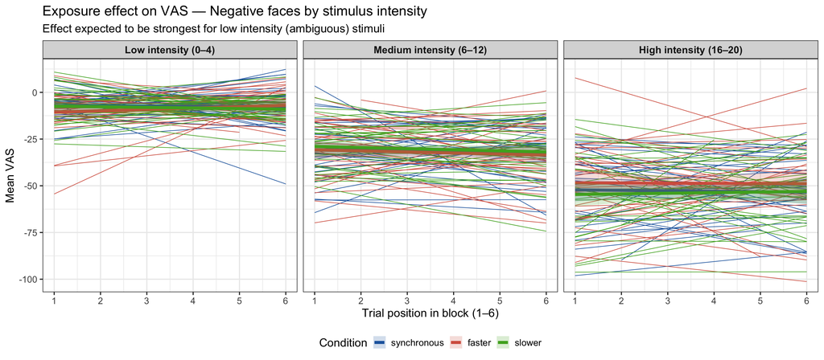

```r
df_raw |>
  filter(valence == "negative") |>
  group_by(participant_id, condition, intensity_cat, trial_in_mini_f) |>
  summarise(vas_m = mean(vas_value, na.rm = TRUE), .groups = "drop") |>
  mutate(trial_num = as.numeric(as.character(trial_in_mini_f))) |>
  ggplot(aes(x = trial_num, y = vas_m,
             color = condition, fill = condition)) +
  geom_smooth(aes(group = interaction(participant_id, condition)),
              method = "lm", se = FALSE,
              linewidth = 0.4, alpha = 0.3) +
  geom_smooth(aes(group = condition),
              method = "lm", se = TRUE,
              linewidth = 2, alpha = 0.2) +
  facet_wrap(~ intensity_cat, labeller = labeller(
    intensity_cat = c(low    = "Low intensity (0–4)",
                      medium = "Medium intensity (6–12)",
                      high   = "High intensity (16–20)"))) +
  scale_x_continuous(breaks = 1:6) +
  scale_color_manual(values = c(synchronous = "#2166ac",
                                faster      = "#d6604d",
                                slower      = "#4dac26")) +
  scale_fill_manual(values  = c(synchronous = "#2166ac",
                                faster      = "#d6604d",
                                slower      = "#4dac26")) +
  labs(title = "Exposure effect on VAS — Negative faces by stimulus intensity",
       subtitle = "Effect expected to be strongest for low intensity (ambiguous) stimuli",
       x = "Trial position in block (1–6)",
       y = "Mean VAS",
       color = "Condition", fill = "Condition") +
  theme_bw(base_size = 16) +
  theme(legend.position = "bottom",
        strip.text = element_text(size = 14, face = "bold"),
        legend.text = element_text(size = 13))
```

## Plot — Group trends only by intensity × valence × condition

Same analysis but showing **only the group trend lines** (no individual participants) across both valences and all three intensity levels. The key prediction: **faster condition should show the steepest positive slope in the negative × low intensity panel**.

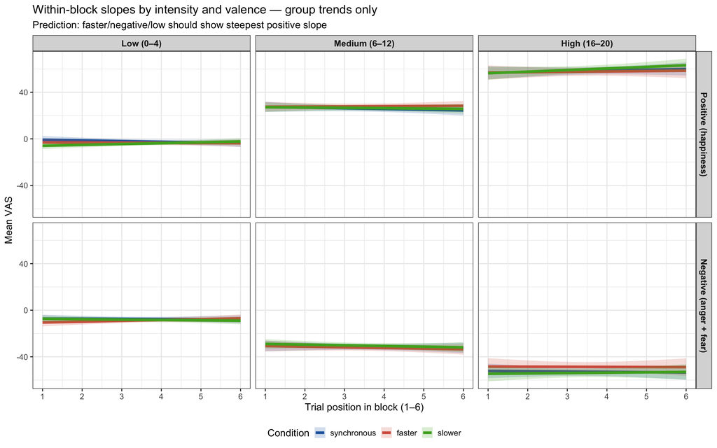

```r
df_raw |>
  group_by(participant_id, condition, valence, intensity_cat, trial_in_mini_f) |>
  summarise(vas_m = mean(vas_value, na.rm = TRUE), .groups = "drop") |>
  mutate(trial_num = as.numeric(as.character(trial_in_mini_f))) |>
  ggplot(aes(x = trial_num, y = vas_m,
             color = condition, fill = condition)) +
  geom_smooth(aes(group = condition),
              method = "lm", se = TRUE,
              linewidth = 2, alpha = 0.2) +
  facet_grid(valence ~ intensity_cat,
             labeller = labeller(
               valence = c(positive = "Positive (happiness)",
                           negative = "Negative (anger + fear)"),
               intensity_cat = c(low    = "Low (0–4)",
                                 medium = "Medium (6–12)",
                                 high   = "High (16–20)"))) +
  scale_x_continuous(breaks = 1:6) +
  scale_color_manual(values = c(synchronous = "#2166ac",
                                faster      = "#d6604d",
                                slower      = "#4dac26")) +
  scale_fill_manual(values  = c(synchronous = "#2166ac",
                                faster      = "#d6604d",
                                slower      = "#4dac26")) +
  labs(title = "Within-block slopes by intensity and valence — group trends only",
       subtitle = "Prediction: faster/negative/low should show steepest positive slope",
       x = "Trial position in block (1–6)",
       y = "Mean VAS",
       color = "Condition", fill = "Condition") +
  theme_bw(base_size = 16) +
  theme(legend.position = "bottom",
        strip.text = element_text(size = 14, face = "bold"),
        legend.text = element_text(size = 13))
```

Key results across all analyses. **Bold rows** = significant at p < .05.

```r
summary_df <- tibble(
  Analysis = c("VAS","VAS","VAS","RT","RT","RT"),
  Effect = c(
    "condition", "valence", "condition x valence x trial",
    "condition", "valence", "condition x valence"
  ),
  F = c(
    round(anova_vas$ANOVA[anova_vas$ANOVA$Effect=="condition","F"], 2),
    round(anova_vas$ANOVA[anova_vas$ANOVA$Effect=="valence","F"], 2),
    round(anova_vas_ts$ANOVA[anova_vas_ts$ANOVA$Effect=="condition:valence:trial_in_mini_f","F"], 2),
    round(anova_rt$ANOVA[anova_rt$ANOVA$Effect=="condition","F"], 2),
    round(anova_rt$ANOVA[anova_rt$ANOVA$Effect=="valence","F"], 2),
    round(anova_rt$ANOVA[anova_rt$ANOVA$Effect=="condition:valence","F"], 2)
  ),
  df = c(
    paste0(anova_vas$ANOVA[anova_vas$ANOVA$Effect=="condition","DFn"],", ",anova_vas$ANOVA[anova_vas$ANOVA$Effect=="condition","DFd"]),
    paste0(anova_vas$ANOVA[anova_vas$ANOVA$Effect=="valence","DFn"],", ",anova_vas$ANOVA[anova_vas$ANOVA$Effect=="valence","DFd"]),
    paste0(anova_vas_ts$ANOVA[anova_vas_ts$ANOVA$Effect=="condition:valence:trial_in_mini_f","DFn"],", ",anova_vas_ts$ANOVA[anova_vas_ts$ANOVA$Effect=="condition:valence:trial_in_mini_f","DFd"]),
    paste0(anova_rt$ANOVA[anova_rt$ANOVA$Effect=="condition","DFn"],", ",anova_rt$ANOVA[anova_rt$ANOVA$Effect=="condition","DFd"]),
    paste0(anova_rt$ANOVA[anova_rt$ANOVA$Effect=="valence","DFn"],", ",anova_rt$ANOVA[anova_rt$ANOVA$Effect=="valence","DFd"]),
    paste0(anova_rt$ANOVA[anova_rt$ANOVA$Effect=="condition:valence","DFn"],", ",anova_rt$ANOVA[anova_rt$ANOVA$Effect=="condition:valence","DFd"])
  ),
  p_raw = c(
    anova_vas$ANOVA[anova_vas$ANOVA$Effect=="condition","p"],
    anova_vas$ANOVA[anova_vas$ANOVA$Effect=="valence","p"],
    anova_vas_ts$ANOVA[anova_vas_ts$ANOVA$Effect=="condition:valence:trial_in_mini_f","p"],
    anova_rt$ANOVA[anova_rt$ANOVA$Effect=="condition","p"],
    anova_rt$ANOVA[anova_rt$ANOVA$Effect=="valence","p"],
    anova_rt$ANOVA[anova_rt$ANOVA$Effect=="condition:valence","p"]
  )
) |>
  mutate(p = case_when(p_raw < 0.001 ~ "< .001", TRUE ~ sprintf("%.3f", p_raw))) |>
  select(Analysis, Effect, F, df, p)

summary_df |>
  kable(escape = FALSE) |>
  kable_styling(bootstrap_options = c("striped","hover"), full_width = FALSE) |>
  row_spec(which(c(
    anova_vas$ANOVA[anova_vas$ANOVA$Effect=="condition","p"],
    anova_vas$ANOVA[anova_vas$ANOVA$Effect=="valence","p"],
    anova_vas_ts$`Sphericity Corrections`[
    anova_vas_ts$`Sphericity Corrections`$Effect=="condition:valence:trial_in_mini_f","p[GG]"],
    anova_rt$ANOVA[anova_rt$ANOVA$Effect=="condition","p"],
    anova_rt$ANOVA[anova_rt$ANOVA$Effect=="valence","p"],
    anova_rt$ANOVA[anova_rt$ANOVA$Effect=="condition:valence","p"]
  ) < 0.05), bold = TRUE)
```

| Analysis | Effect | F | df | p |
| --- | --- | --- | --- | --- |
| VAS | condition | 0.16 | 2, 58 | 0.855 |
| VAS | valence | 377.63 | 1, 29 | < .001 |
| VAS | condition x valence x trial | 1.28 | 10, 290 | 0.242 |
| RT | condition | 3.07 | 2, 58 | 0.054 |
| RT | valence | 0.12 | 1, 29 | 0.729 |
| RT | condition x valence | 1.65 | 2, 58 | 0.201 |

**Notes:**

*Report generated automatically from raw `*_FULL.csv` files.*  
*2026-08-11 11:38*